# Tugas Pertemuan 2

# Seasonal Smoothing

## Pembagian Data

Selanjutnya melakukan pembagian data dan mengubahnya menjadi data deret waktu.

```r
## Pembagian Data

# Membagi data menjadi training dan testing
n <- nrow(data_1)

# 80% data training
n_train <- floor(0.8 * n)

training <- data_1[1:n_train, ]
testing  <- data_1[(n_train + 1):n, ]

# Mengubah menjadi data deret waktu
training.ts <- ts(
  training$CES9093161101,
  frequency = 12
)

testing.ts <- ts(
  testing$CES9093161101,
  frequency = 12
)
```

Kemudian akan dilakukan eskplorasi dengan plot data deret waktu sebagai berikut.

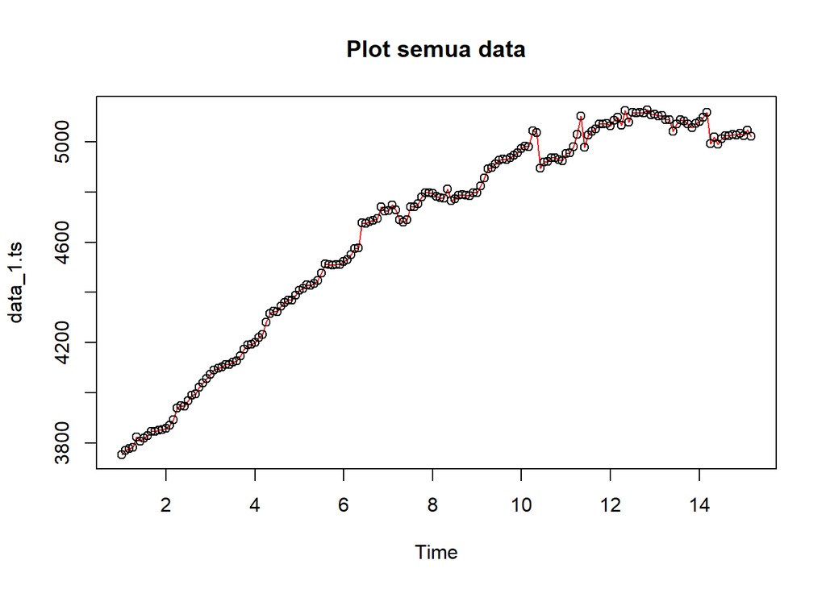

```r
# Plot keseluruhan data
plot(data_1.ts, col = "red", main = "Plot semua data")
points(data_1.ts)
```

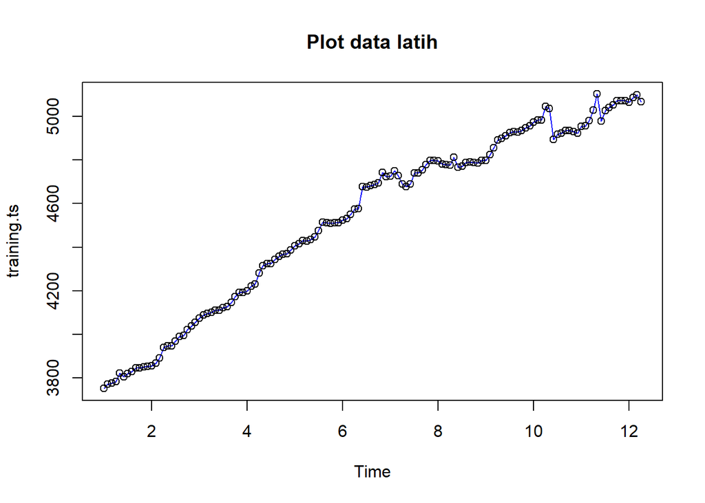

```r
# Plot data latih
plot(training.ts, col = "blue", main = "Plot data latih")
points(training.ts)
```

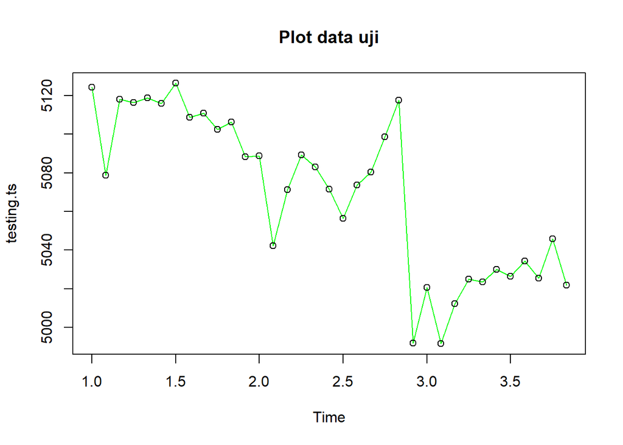

```r
# Plot data uji
plot(testing.ts, col = "green", main = "Plot data uji")
points(testing.ts)
```

$$L_t = \alpha(Y_t - S_{t-s}) +
(1-\alpha)(L_{t-1} + B_{t-1})$$

$$B_t = \beta(L_t - L_{t-1}) +
(1-\beta)B_{t-1}$$
$$S_t = \gamma(Y_t
- L_t) + (1-\gamma)S_{t-s}$$

Pemulusan data musiman dengan metode Winter dilakukan menggunakan fungsi `HoltWinters()` dengan memasukkan argumen tambahan, yaitu `gamma()` dan `seasonal()` . Arguman `seasonal()` diinisialisasi menyesuaikan jenis musiman, aditif atau multiplikatif.

### Winter Aditif

Perhitungan dengan model aditif dilakukan jika plot data asli menunjukkan fluktuasi musiman yang relatif stabil (konstan).

#### Pemulusan

```r
# Pemulusan dengan Winter Aditif
winter1 <- HoltWinters(
  training.ts,
  alpha = 0.2,
  beta = 0.1,
  gamma = 0.1,
  seasonal = "additive"
)

winter1$fitted
```

```
##            xhat    level     trend       season
## Jan  2 3790.983 3799.560 12.170149 -20.74687500
## Feb  2 3817.328 3824.953 13.492490 -21.11770833
## Mar  2 3853.283 3848.900 14.537930 -10.15520833
## Apr  2 3909.472 3871.461 15.340273  22.66979167
## May  2 3924.350 3892.847 15.944842  15.55729167
## Jun  2 3928.252 3913.462 16.411851  -1.62187500
## Jul  2 3955.691 3933.584 16.782804   5.32395833
## Aug  2 3977.002 3952.888 17.034994   7.07812500
## Sep  2 4004.855 3972.523 17.294962  15.03645833
## Oct  2 4008.731 3987.767 17.089871   3.87395833
## Nov  2 4021.332 4007.591 17.363251  -3.62187500
## Dec  2 4033.774 4028.348 17.702607 -12.27604167
## Jan  3 4053.405 4050.695 18.167122 -15.45750962
## Feb  3 4074.757 4073.102 18.591022 -16.93594855
## Mar  3 4106.603 4094.661 18.887889  -6.94583490
## Apr  3 4155.478 4111.688 18.701824  25.08806855
## May  3 4154.884 4119.815 17.644256  17.42532578
## Jun  3 4145.443 4128.802 16.778572  -0.13806246
## Jul  3 4161.379 4138.932 16.113721   6.33271737
## Aug  3 4170.878 4147.410 15.350151   8.11799938
## Sep  3 4182.805 4154.105 14.484585  14.21609417
## Oct  3 4180.362 4161.608 13.786480   4.96747729
## Nov  3 4185.341 4173.962 13.643238  -2.26445326
## Dec  3 4192.252 4188.897 13.772418 -10.41797947
## Jan  4 4202.801 4202.779 13.783385 -13.76191220
## Feb  4 4214.091 4216.103 13.737369 -15.74847723
## Mar  4 4237.363 4231.182 13.871540  -7.69009808
## Apr  4 4278.537 4243.921 13.758278  20.85779985
## May  4 4286.206 4258.412 13.831546  13.96258972
## Jun  4 4289.502 4277.902 14.397433  -2.79746603
## Jul  4 4317.851 4299.459 15.113395   3.27843441
## Aug  4 4335.716 4315.822 15.238379   4.65573839
## Sep  4 4359.721 4332.877 15.420052  11.42367096
## Oct  4 4368.041 4348.233 15.413631   4.39450969
## Nov  4 4377.458 4363.779 15.426805  -1.74773192
## Dec  4 4382.507 4377.614 15.267653 -10.37411375
## Jan  5 4395.412 4393.980 15.377506 -13.94597577
## Feb  5 4412.205 4411.795 15.621275 -15.21179237
## Mar  5 4435.642 4428.096 15.689182  -8.14314372
```

[output cut: 70 more lines]

```
## Feb 11 4950.869 4961.943  1.317988 -12.39184905
## Mar 11 4955.604 4964.467  1.438611 -10.30154699
## Apr 11 4982.531 4970.725  1.920531   9.88600817
## May 11 4991.291 4981.979  2.853905   6.45793170
## Jun 11 4999.686 5006.995  5.070088 -12.37853895
## Jul 11 5009.085 5007.828  4.646362  -3.38931770
## Aug 11 5020.699 5016.117  5.010670  -0.42849853
## Sep 11 5034.028 5025.308  5.428686   3.29145773
## Oct 11 5039.546 5034.291  5.784126  -0.52880556
## Nov 11 5050.336 5046.626  6.439201  -2.72930092
## Dec 11 5054.150 5057.438  6.876487 -10.16397562
## Jan 12 5064.584 5068.064  7.251479 -10.73220772
## Feb 12 5070.662 5075.319  7.251808 -11.90935672
## Mar 12 5084.911 5085.719  7.566578  -8.37386616
## Apr 12 5117.549 5096.083  7.846353  13.61950594
```

```r
xhat1 <- winter1$fitted[,2]

# Winter Aditif dengan parameter optimum
winter1.opt <- HoltWinters(
  training.ts,
  alpha = NULL,
  beta = NULL,
  gamma = NULL,
  seasonal = "additive"
)

winter1.opt
```

```
## Holt-Winters exponential smoothing with trend and additive seasonal component.
##
## Call:
## HoltWinters(x = training.ts, alpha = NULL, beta = NULL, gamma = NULL,     seasonal = "additive")
##
## Smoothing parameters:
##  alpha: 0.9135296
##  beta : 0
##  gamma: 0.5115549
##
## Coefficients:
##             [,1]
## a   5058.7218148
## b     12.1701486
## s1    17.2197861
## s2    -7.6177445
## s3     6.4848216
## s4     6.6137926
## s5    10.6579000
## s6     6.4667478
## s7    -0.8525286
## s8   -11.3851606
## s9   -16.5006650
## s10  -19.3353182
## s11  -14.5322941
## s12   10.6784116
```

```r
winter1.opt$fitted
```

```
##            xhat    level    trend       season
## Jan  2 3790.983 3799.560 12.17015 -20.74687500
## Feb  2 3863.182 3872.130 12.17015 -21.11770833
## Mar  2 3892.178 3890.163 12.17015 -10.15520833
## Apr  2 3938.289 3903.450 12.17015  22.66979167
## May  2 3944.636 3916.908 12.17015  15.55729167
## Jun  2 3942.426 3931.878 12.17015  -1.62187500
## Jul  2 3965.538 3948.044 12.17015   5.32395833
## Aug  2 3981.985 3962.737 12.17015   7.07812500
## Sep  2 4009.435 3982.229 12.17015  15.03645833
## Oct  2 3996.890 3980.846 12.17015   3.87395833
## Nov  2 4024.868 4016.320 12.17015  -3.62187500
## Dec  2 4040.655 4040.760 12.17015 -12.27604167
## Jan  3 4062.211 4067.863 12.17015 -17.82223033
## Feb  3 4082.687 4091.351 12.17015 -20.83381893
## Mar  3 4111.905 4109.836 12.17015 -10.10114047
## Apr  3 4143.566 4108.664 12.17015  22.73218617
## May  3 4111.273 4083.410 12.17015  15.69283991
## Jun  3 4106.621 4095.879 12.17015  -1.42839440
## Jul  3 4130.762 4113.146 12.17015   5.44614413
## Aug  3 4138.011 4118.408 12.17015   7.43264271
## Sep  3 4147.618 4121.068 12.17015  14.38022150
## Oct  3 4150.668 4133.495 12.17015   5.00235521
## Nov  3 4175.392 4166.249 12.17015  -3.02774139
## Dec  3 4194.026 4193.409 12.17015 -11.55301174
## Jan  4 4199.355 4204.459 12.17015 -17.27419181
## Feb  4 4209.317 4217.675 12.17015 -20.52803762
## Mar  4 4241.758 4240.335 12.17015 -10.74718643
## Apr  4 4276.407 4243.317 12.17015  20.92006542
## May  4 4288.656 4260.779 12.17015  15.70729657
## Jun  4 4307.547 4296.558 12.17015  -1.18159573
## Jul  4 4342.228 4324.946 12.17015   5.11163349
## Aug  4 4339.698 4320.556 12.17015   6.97213863
## Sep  4 4363.950 4337.387 12.17015  14.39269859
## Oct  4 4363.570 4345.401 12.17015   5.99904809
## Nov  4 4372.126 4362.257 12.17015  -2.30193078
## Dec  4 4372.592 4372.029 12.17015 -11.60724507
## Jan  5 4393.222 4398.275 12.17015 -17.22354284
## Feb  5 4415.730 4423.580 12.17015 -20.02010768
## Mar  5 4436.609 4435.631 12.17015 -11.19209920
```

[output cut: 70 more lines]

```
## Feb 11 4961.394 4968.906 12.17015 -19.68189400
## Mar 11 4974.564 4976.971 12.17015 -14.57655218
## Apr 11 5019.499 4993.832 12.17015  13.49619253
## May 11 5041.578 5014.865 12.17015  14.54262280
## Jun 11 5091.892 5082.324 12.17015  -2.60191444
## Jul 11 5008.741 4990.907 12.17015   5.66387677
## Aug 11 5038.686 5020.031 12.17015   6.48491057
## Sep 11 5057.964 5034.863 12.17015  10.93055386
## Oct 11 5059.472 5041.402 12.17015   5.89930480
## Nov 11 5076.813 5065.291 12.17015  -0.64847019
## Dec 11 5074.085 5073.247 12.17015 -11.33275336
## Jan 12 5080.718 5084.335 12.17015 -15.78771204
## Feb 12 5074.071 5081.781 12.17015 -19.88068910
## Mar 12 5103.035 5105.215 12.17015 -14.34936904
## Apr 12 5139.702 5113.607 12.17015  13.92531912
```

```r
xhat1.opt <- winter1.opt$fitted[,2]
```

#### Peramalan

```r
# Forecast sebanyak jumlah data uji
n_test <- nrow(testing)
forecast1 <- predict(winter1, n.ahead = n_test)
forecast1.opt <- predict(winter1.opt,n.ahead = n_test)
forecast1
```

```
##         Jan      Feb      Mar      Apr      May      Jun      Jul      Aug
## 12                                     5115.824 5093.249 5112.212 5122.209
## 13 5144.341 5151.243 5161.460 5185.056 5197.680 5175.105 5194.068 5204.065
## 14 5226.198 5233.100 5243.316 5266.912 5279.537 5256.962 5275.925 5285.922
## 15 5308.054 5314.956 5325.173
##         Sep      Oct      Nov      Dec
## 12 5132.500 5136.699 5140.449 5139.587
## 13 5214.356 5218.556 5222.306 5221.443
## 14 5296.213 5300.412 5304.162 5303.300
## 15
```

```r
forecast1.opt
```

```
##         Jan      Feb      Mar      Apr      May      Jun      Jul      Aug
## 12                                     5088.112 5075.444 5101.717 5114.016
## 13 5151.752 5161.088 5178.061 5215.442 5234.154 5221.486 5247.759 5260.058
## 14 5297.794 5307.130 5324.103 5361.484 5380.195 5367.528 5393.801 5406.100
## 15 5443.836 5453.172 5470.145
##         Sep      Oct      Nov      Dec
## 12 5130.230 5138.209 5143.060 5144.698
## 13 5276.272 5284.251 5289.102 5290.740
## 14 5422.314 5430.293 5435.144 5436.781
## 15
```

#### Plot Deret Waktu

[figure not shown]

```r
plot(
  train.ts,
  main = "Winter Aditif α=0.2; β=0.1; γ=0.1",
  type = "l",
  col = "black",
  xlim = c(1, 171)
)

lines(xhat1, col = "red")
lines(xhat1.opt, col = "blue")

lines(
  ts(forecast1, start = 137, frequency = 12),
  col = "red"
)

lines(
  ts(forecast1.opt, start = 137, frequency = 12),
  col = "blue"
)

legend(
  "topleft",
  c("Actual Data", "Winter 0.2;0.1;0.1", "Winter Optimum"),
  col = c("black", "red", "blue"),
  lty = 1,
  cex = 0.7
)
```

#### Akurasi Data Latih

```r
#Akurasi data training
SSE1<-winter1$SSE
MSE1<-winter1$SSE/length(training.ts)
RMSE1<-sqrt(MSE1)
akurasi1 <- matrix(c(SSE1,MSE1,RMSE1))
row.names(akurasi1)<- c("SSE", "MSE", "RMSE")
colnames(akurasi1) <- c("Akurasi")
akurasi1
```

```
##           Akurasi
## SSE  176711.19425
## MSE    1299.34702
## RMSE     36.04646
```

```r
SSE1.opt<-winter1.opt$SSE
MSE1.opt<-winter1.opt$SSE/length(training.ts)
RMSE1.opt<-sqrt(MSE1.opt)
akurasi1.opt <- matrix(c(SSE1.opt,MSE1.opt,RMSE1.opt))
row.names(akurasi1.opt)<- c("SSE1.opt", "MSE1.opt", "RMSE1.opt")
colnames(akurasi1.opt) <- c("Akurasi")
akurasi1.opt
```

```
##               Akurasi
## SSE1.opt  94443.19573
## MSE1.opt    694.43526
## RMSE1.opt    26.35214
```

```r
akurasi1.train = data.frame(Model_Winter = c("Winter 1","Winter1 optimal"),
                            Nilai_SSE=c(SSE1,SSE1.opt),
                            Nilai_MSE=c(MSE1,MSE1.opt),Nilai_RMSE=c(RMSE1,RMSE1.opt))
akurasi1.train
```

```
##      Model_Winter Nilai_SSE Nilai_MSE Nilai_RMSE
## 1        Winter 1  176711.2 1299.3470   36.04646
## 2 Winter1 optimal   94443.2  694.4353   26.35214
```

#### Akurasi Data Uji

```r
# Forecast sebanyak jumlah data uji
n_test <- nrow(testing)

forecast1 <- predict(winter1, n.ahead = n_test)
forecast1.opt <- predict(winter1.opt, n.ahead = n_test)

forecast1
```

```
##         Jan      Feb      Mar      Apr      May      Jun      Jul      Aug
## 12                                     5115.824 5093.249 5112.212 5122.209
## 13 5144.341 5151.243 5161.460 5185.056 5197.680 5175.105 5194.068 5204.065
## 14 5226.198 5233.100 5243.316 5266.912 5279.537 5256.962 5275.925 5285.922
## 15 5308.054 5314.956 5325.173
##         Sep      Oct      Nov      Dec
## 12 5132.500 5136.699 5140.449 5139.587
## 13 5214.356 5218.556 5222.306 5221.443
## 14 5296.213 5300.412 5304.162 5303.300
## 15
```

```r
forecast1.opt
```

```
##         Jan      Feb      Mar      Apr      May      Jun      Jul      Aug
## 12                                     5088.112 5075.444 5101.717 5114.016
## 13 5151.752 5161.088 5178.061 5215.442 5234.154 5221.486 5247.759 5260.058
## 14 5297.794 5307.130 5324.103 5361.484 5380.195 5367.528 5393.801 5406.100
## 15 5443.836 5453.172 5470.145
##         Sep      Oct      Nov      Dec
## 12 5130.230 5138.209 5143.060 5144.698
## 13 5276.272 5284.251 5289.102 5290.740
## 14 5422.314 5430.293 5435.144 5436.781
## 15
```

```r
# Akurasi Data Testing

# Jumlah data uji
n_test <- nrow(testing)

# Ambil hasil forecast
forecast1_test <- as.numeric(forecast1)[1:n_test]
forecast1_opt_test <- as.numeric(forecast1.opt)[1:n_test]

# Data aktual
aktual_test <- as.numeric(testing$CES9093161101)

# Pastikan panjang forecast dan data aktual sama
forecast1_test <- forecast1_test[1:length(aktual_test)]
forecast1_opt_test <- forecast1_opt_test[1:length(aktual_test)]

# Error
selisih1 <- forecast1_test - aktual_test
selisih1.opt <- forecast1_opt_test - aktual_test

# SSE
SSEtesting1 <- sum(selisih1^2)
SSEtesting1.opt <- sum(selisih1.opt^2)

# MSE
MSEtesting1 <- SSEtesting1 / length(aktual_test)
MSEtesting1.opt <- SSEtesting1.opt / length(aktual_test)

# Tabel akurasi
akurasi_testing <- data.frame(
  Model = c("Winter Aditif", "Winter Aditif Optimum"),
  SSE = c(SSEtesting1, SSEtesting1.opt),
  MSE = c(MSEtesting1, MSEtesting1.opt)
)

akurasi_testing
```

```
##                   Model     SSE      MSE
## 1         Winter Aditif 1111254 31750.11
## 2 Winter Aditif Optimum 2349497 67128.48
```

### Winter Multiplikatif

Model multiplikatif digunakan cocok digunakan jika plot data asli menunjukkan fluktuasi musiman yang bervariasi.

#### Pemulusan

```r
#Pemulusan dengan winter multiplikatif
winter2 <- HoltWinters(training.ts,alpha=0.2,beta=0.1,gamma=0.3,seasonal = "multiplicative")
winter2$fitted
```

```
##            xhat    level      trend    season
## Jan  2 3791.334 3799.560 12.1701486 0.9946491
## Feb  2 3817.621 3824.954 13.4925516 0.9945745
## Mar  2 3853.406 3848.899 14.5378073 0.9974036
## Apr  2 3909.323 3871.456 15.3397739 1.0057958
## May  2 3924.291 3892.837 15.9438083 1.0039682
## Jun  2 3928.300 3913.444 16.4101369 0.9996046
## Jul  2 3955.787 3933.555 16.7802863 1.0013799
## Aug  2 3977.161 3952.835 17.0302075 1.0018377
## Sep  2 4005.325 3972.428 17.2865254 1.0039125
## Oct  2 4008.652 3987.578 17.0728702 1.0009991
## Nov  2 4020.939 4007.398 17.3475584 0.9990542
## Dec  2 4033.053 4028.221 17.6951110 0.9968208
## Jan  3 4063.915 4050.721 18.1755706 0.9987757
## Feb  3 4080.493 4071.036 18.3895411 0.9978157
## Mar  3 4109.342 4091.251 18.5720843 0.9998829
## Apr  3 4157.384 4107.414 18.3312178 1.0076686
## May  3 4154.445 4114.872 17.2438742 1.0054038
## Jun  3 4143.021 4123.593 16.3915798 1.0007333
## Jul  3 4158.479 4133.825 15.7756183 1.0021397
## Aug  3 4168.497 4142.560 15.0715362 1.0026135
## Sep  3 4177.332 4149.473 14.2557257 1.0032671
## Oct  3 4179.133 4157.862 13.6690008 1.0018224
## Nov  3 4184.267 4170.346 13.5505566 1.0000886
## Dec  3 4191.712 4185.403 13.7011954 0.9982396
## Jan  4 4210.541 4199.322 13.7229850 0.9994056
## Feb  4 4217.587 4211.036 13.5220434 0.9983499
## Mar  4 4235.309 4225.202 13.5864097 0.9991793
## Apr  4 4270.598 4238.066 13.5141641 1.0044733
## May  4 4280.054 4253.890 13.7451664 1.0029101
## Jun  4 4284.407 4274.504 14.4320829 0.9989440
## Jul  4 4312.787 4297.123 15.2508095 1.0000958
## Aug  4 4331.188 4314.637 15.4770448 1.0002480
## Sep  4 4355.404 4332.835 15.7492260 1.0015682
## Oct  4 4371.676 4349.383 15.8290210 1.0014810
## Nov  4 4382.667 4364.617 15.7695805 1.0005205
## Dec  4 4385.800 4377.755 15.5063813 0.9983018
## Jan  5 4404.108 4393.702 15.5504463 0.9988333
## Feb  5 4419.077 4409.951 15.6203644 0.9985324
## Mar  5 4435.874 4424.875 15.5507242 0.9989749
```

[output cut: 70 more lines]

```
## Feb 11 4957.195 4961.119  0.9539348 0.9990169
## Mar 11 4954.819 4962.014  0.9480382 0.9983592
## Apr 11 4977.386 4967.946  1.4464811 1.0016085
## May 11 4984.186 4979.739  2.4810969 1.0003946
## Jun 11 4973.359 5005.794  4.8384445 0.9925612
## Jul 11 4995.208 5011.668  4.9420370 0.9957338
## Aug 11 5012.433 5023.056  5.5866192 0.9967766
## Sep 11 5028.207 5034.495  6.1718373 0.9975281
## Oct 11 5040.624 5045.397  6.6448754 0.9977399
## Nov 11 5056.269 5058.391  7.2798379 0.9981439
## Dec 11 5062.860 5068.863  7.5990538 0.9973204
## Jan 12 5080.437 5078.476  7.8003974 0.9988520
## Feb 12 5085.511 5083.105  7.4832883 0.9990026
## Mar 12 5096.030 5090.766  7.5010819 0.9995612
## Apr 12 5127.365 5098.842  7.5584996 1.0041056
```

```r
xhat2 <- winter2$fitted[,2]

winter2.opt<- HoltWinters(training.ts, alpha= NULL,  beta = NULL, gamma = NULL, seasonal = "multiplicative")
winter2.opt$fitted
```

```
##            xhat    level    trend    season
## Jan  2 3791.334 3799.560 12.17015 0.9946491
## Feb  2 3864.127 3873.037 12.17015 0.9945745
## Mar  2 3892.346 3890.309 12.17015 0.9974036
## Apr  2 3938.322 3903.458 12.17015 1.0057958
## May  2 3944.660 3916.898 12.17015 1.0039682
## Jun  2 3942.487 3931.876 12.17015 0.9996046
## Jul  2 3965.682 3948.047 12.17015 1.0013799
## Aug  2 3982.116 3962.641 12.17015 1.0018377
## Sep  2 4009.906 3982.108 12.17015 1.0039125
## Oct  2 3996.300 3980.142 12.17015 1.0009991
## Nov  2 4024.847 4016.487 12.17015 0.9990542
## Dec  2 4040.427 4041.143 12.17015 0.9968208
## Jan  3 4063.169 4068.729 12.17015 0.9956555
## Feb  3 4081.791 4091.544 12.17015 0.9946578
## Mar  3 4112.524 4110.993 12.17015 0.9974196
## Apr  3 4145.153 4109.011 12.17015 1.0058166
## May  3 4110.558 4081.954 12.17015 1.0040140
## Jun  3 4105.899 4095.087 12.17015 0.9996693
## Jul  3 4131.126 4113.101 12.17015 1.0014191
## Aug  3 4138.178 4117.933 12.17015 1.0019551
## Sep  3 4147.711 4120.315 12.17015 1.0036846
## Oct  3 4150.566 4132.659 12.17015 1.0013842
## Nov  3 4174.829 4165.786 12.17015 0.9992515
## Dec  3 4193.518 4193.704 12.17015 0.9970622
## Jan  4 4199.752 4205.206 12.17015 0.9958210
## Feb  4 4208.120 4218.073 12.17015 0.9947704
## Mar  4 4242.320 4242.061 12.17015 0.9972000
## Apr  4 4278.656 4244.357 12.17015 1.0051988
## May  4 4289.178 4259.796 12.17015 1.0040291
## Jun  4 4306.487 4295.350 12.17015 0.9997601
## Jul  4 4342.798 4324.968 12.17015 1.0013050
## Aug  4 4339.804 4319.824 12.17015 1.0018029
## Sep  4 4364.823 4336.618 12.17015 1.0036873
## Oct  4 4363.380 4343.778 12.17015 1.0017062
## Nov  4 4370.818 4360.872 12.17015 0.9994913
## Dec  4 4371.066 4371.820 12.17015 0.9970521
## Jan  5 4393.517 4399.737 12.17015 0.9958315
## Feb  5 4414.772 4425.020 12.17015 0.9949476
## Mar  5 4437.012 4437.962 12.17015 0.9970517
```

[output cut: 70 more lines]

```
## Feb 11 4960.190 4972.209 12.17015 0.9951470
## Mar 11 4973.944 4981.314 12.17015 0.9960869
## Apr 11 5024.418 4998.842 12.17015 1.0026754
## May 11 5045.483 5015.434 12.17015 1.0035562
## Jun 11 5089.932 5079.913 12.17015 0.9995776
## Jul 11 5008.497 4988.719 12.17015 1.0015212
## Aug 11 5038.749 5018.297 12.17015 1.0016464
## Sep 11 5058.608 5033.106 12.17015 1.0026425
## Oct 11 5059.704 5038.980 12.17015 1.0016935
## Nov 11 5075.454 5062.809 12.17015 1.0000935
## Dec 11 5070.692 5071.963 12.17015 0.9973563
## Jan 12 5079.443 5086.186 12.17015 0.9962904
## Feb 12 5071.778 5084.542 12.17015 0.9951079
## Mar 12 5102.811 5110.336 12.17015 0.9961552
## Apr 12 5145.053 5118.866 12.17015 1.0027319
```

```r
xhat2.opt <- winter2.opt$fitted[,2]
```

```r
# Forecast sebanyak jumlah data uji
n_test <- nrow(testing)
forecast2 <- predict(winter2, n.ahead = n_test)
forecast2.opt <- predict(winter2.opt,n.ahead = n_test)
forecast2
```

```
##         Jan      Feb      Mar      Apr      May      Jun      Jul      Aug
## 12                                     5131.427 5070.189 5099.290 5110.222
## 13 5141.551 5152.731 5162.433 5176.696 5207.994 5145.748 5175.188 5186.189
## 14 5217.513 5228.764 5238.516 5252.896 5284.560 5221.307 5251.086 5262.155
## 15 5293.475 5304.798 5314.599
##         Sep      Oct      Nov      Dec
## 12 5119.030 5128.404 5132.971 5133.630
## 13 5195.034 5204.453 5208.993 5209.568
## 14 5271.037 5280.501 5285.015 5285.506
## 15
```

```r
forecast2.opt
```

```
##         Jan      Feb      Mar      Apr      May      Jun      Jul      Aug
## 12                                     5091.765 5073.679 5103.607 5115.474
## 13 5147.682 5155.454 5171.888 5213.672 5238.423 5219.466 5249.903 5261.761
## 14 5293.156 5300.806 5317.362 5359.978 5385.081 5365.253 5396.199 5408.049
## 15 5438.631 5446.158 5462.836
##         Sep      Oct      Nov      Dec
## 12 5132.182 5140.682 5143.691 5142.079
## 13 5278.598 5286.992 5289.741 5287.738
## 14 5425.014 5433.303 5435.790 5433.397
## 15
```